# WEATHER FORECASTING

## CLUSTER ANALYSIS AND DECISION TREE INDUCTION

**Importing all the required libraries**

```python
import math
import numpy as np
import pandas as pd
import missingno as mn
import matplotlib.pyplot as plt
import seaborn as sb
from sklearn.preprocessing import StandardScaler
from sklearn.preprocessing import MinMaxScaler
from sklearn.model_selection import train_test_split
from sklearn.tree import DecisionTreeClassifier
from sklearn.tree import plot_tree
from sklearn.model_selection import GridSearchCV
from sklearn.metrics import roc_curve,roc_auc_score
from sklearn.metrics import auc
from sklearn.metrics import accuracy_score,confusion_matrix
from sklearn.cluster import KMeans,AgglomerativeClustering
from sklearn.metrics import silhouette_score
from scipy.spatial.distance import cdist
from sklearn.metrics import classification_report,precision_score
from sklearn.metrics import recall_score,f1_score
```

**Ignoring warning messages and setting the plot style and palette**

```python
import warnings
warnings.filterwarnings('ignore')
%matplotlib inline
sb.set_palette('hls')
```

## SECTION 1 : DATA PREPARATION

**Reading the Weather Forecasting Training Data**

```python
data = pd.read_csv('train.csv')
```

**Exploring the dataset**

```python
print('Dimensions of the dataset : {}'.format(data.shape))
data.head(5)
```

```
Dimensions of the dataset : (51978, 16)
```

|  | Location | MinTemp | MaxTemp | Rainfall | Evaporation | Sunshine | WindGustDir | WindGustSpeed | WindDir | WindSpeed | Humidity | Pressure | Cloud | Temp | RainToday | RainTomorrow |
| --- | --- | --- | --- | --- | --- | --- | --- | --- | --- | --- | --- | --- | --- | --- | --- | --- |
| 0 | NorahHead | 18.9 | 23.7 | 0.0 | NaN | NaN | SSE | 41.0 | SSE | 28.0 | 55.0 | 1026.0 | NaN | 22.4 | No | Yes |
| 1 | Nuriootpa | 11.1 | 20.8 | 0.0 | 4.8 | 8.3 | W | 39.0 | WSW | 26.0 | 48.0 | 1014.4 | 7.0 | 19.5 | No | No |
| 2 | GoldCoast | 15.9 | 19.5 | 17.6 | NaN | NaN | SE | 44.0 | SW | 9.0 | 99.0 | 1028.5 | NaN | 17.8 | Yes | Yes |
| 3 | Bendigo | 0.0 | 14.9 | 0.0 | NaN | NaN | WSW | 35.0 | WNW | 19.0 | 55.0 | 1023.0 | 4.0 | 14.2 | No | Yes |
| 4 | Walpole | 9.1 | 22.7 | 0.0 | NaN | NaN | NNE | 41.0 | ESE | 7.0 | 40.0 | 1027.1 | NaN | 22.5 | No | No |

**Missing values**

```python
total = data.isnull().sum()
percent = (data.isnull().sum()/data.isnull().count())*100
missing_data = pd.concat([total, percent], axis=1, keys=['Total', 'Percent'])
missing_data.head(20)
```

|  | Total | Percent |
| --- | --- | --- |
| Location | 0 | 0.000000 |
| MinTemp | 284 | 0.546385 |
| MaxTemp | 129 | 0.248182 |
| Rainfall | 747 | 1.437146 |
| Evaporation | 22553 | 43.389511 |
| Sunshine | 24875 | 47.856786 |
| WindGustDir | 3598 | 6.922159 |
| WindGustSpeed | 3571 | 6.870214 |
| WindDir | 1513 | 2.910847 |
| WindSpeed | 1024 | 1.970064 |
| Humidity | 1429 | 2.749240 |
| Pressure | 5066 | 9.746431 |
| Cloud | 20130 | 38.727923 |
| Temp | 1063 | 2.045096 |
| RainToday | 747 | 1.437146 |
| RainTomorrow | 0 | 0.000000 |

**Visualizing missing values in each column**

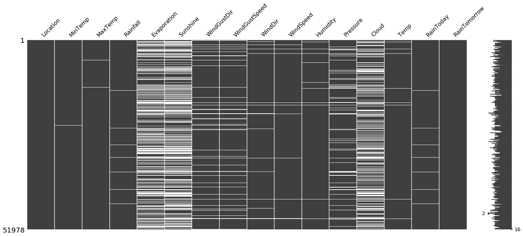

```python
plt.show(mn.matrix(data))
```

*All the whitespaces in the plot are missing values in the respective columns.*

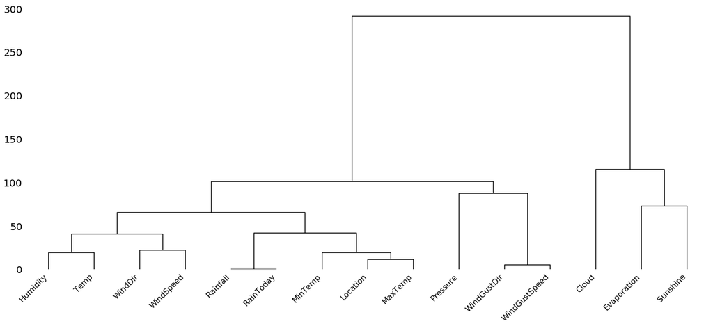

```python
mn.dendrogram(data.drop(columns=['RainTomorrow']),orientation='top',method='ward')
plt.show()
```

*Based on the above visualizations, Since a lot of data is missing in Evaporation, Sunshine and Cloud, I have decided to drop those columns.*

```python
data.drop(columns=['Evaporation','Sunshine','Cloud'],inplace=True)
```

**Dealing with missing values in Numerical variables**

*Now we have to deal with the missing values in the remaining columns. For numerical variables, I filled the missing values using the median of the column that is calculated after grouping the observations by Location variable.*

```python
for i in ['MinTemp', 'MaxTemp', 'Rainfall', 'WindSpeed', 'Humidity','Temp']:
    data[i]=data.groupby(['Location'])[i].transform(lambda x: x.fillna(x.median()))
```

```python
for i in ['Pressure','WindGustSpeed']:
    data[i].fillna(data[i].median(),inplace=True)
```

**Dealing with missing values in Categorical variables**

*There is no missing data in target variable, but for further use in modelling it is advisable to convert it to binary type. So target variable is replaced with 1 for No and 0 for Yes.*

```python
data.replace({'RainTomorrow':{'Yes':0,'No':1}},inplace=True)
```

*For the rest of categorical variables, the missing values are replaced by the mode of the entire column.*

```python
for i in ['WindGustDir','WindDir','RainToday']:
    data[i].fillna(data[i].mode()[0],inplace=True)
```

**Visualization of Numerical variables and Outlier Detection**

**Box Plots**

*We are going to visualize the numerical variables using boxplots. Outliers can also be detected by using boxplot.*

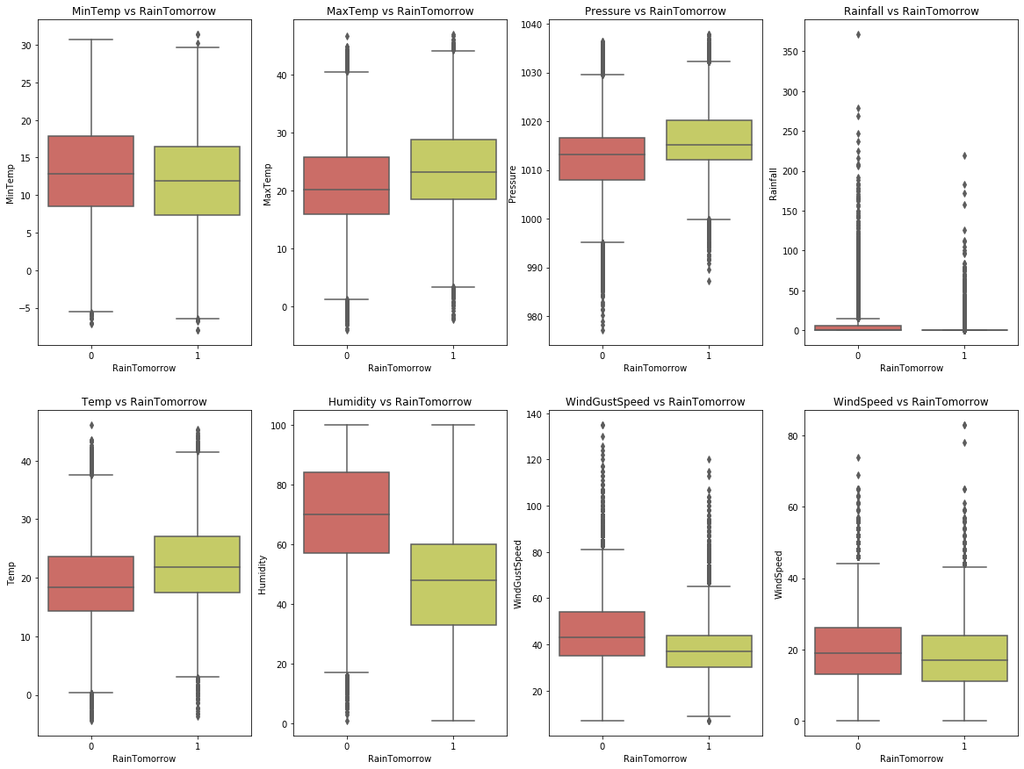

```python
num = ['MinTemp', 'MaxTemp', 'Pressure', 'Rainfall', 'Temp', 'Humidity', 'WindGustSpeed', 'WindSpeed']

plt.figure(figsize=(20,15))

for i in range(len(num)):
    plt.subplot(2,4,i+1)
    sb.boxplot(x='RainTomorrow',y=num[i],data=data)
    plt.title('{} vs RainTomorrow'.format(num[i]))
```

**Interpretation of the boxplots**

*For MinTemperature, we can observe that if it rains tomorrow if the MinTemperature is slightly be higher compared to no rain.*

*For MaxTemperature, we can observe that if it rains tomorrow if the MaxTemperature is lower compared to no rain.*

*For Pressure, we can observe that the range of Pressure is higher when there is no rain tomorrow.*

*For Rainfall, we can observe that when it rains tomorrow the range of Rainfall is higher.*

*For Temperature, we can observe that the Temperature is lower when there is rain tomorrow.*

*For Humidity, we can observe that the Humidity is very high when it rains compared to no rain.*

*For WindGustSpeed, we can observe that WindGustSpeed is higher when there is rain tomorrow.*

*For WindSpeed, we can observe that WindSpeed is slightly higher when it rains tomorrow*

**Kernel Density Estimation Plots**

*Plotted kde plots to have a look at the distribution of the numerical variables*

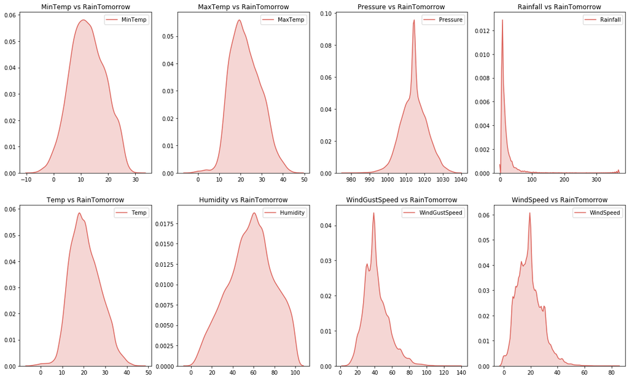

```python
numd = ['MinTemp', 'MaxTemp', 'Pressure', 'Rainfall', 'Temp', 'Humidity', 'WindGustSpeed', 'WindSpeed']

plt.figure(figsize=(20,12))

for i in range(len(numd)):
    plt.subplot(2,4,i+1)
    sb.kdeplot(data[numd[i]],shade=True)
    plt.title('{} vs RainTomorrow'.format(numd[i]))
```

*Most of the variables display normal distribution or slight skewness.*

*Variables like WindGustSpeed, WindSpeed and Rainfall are highly skewed to the right.*

**Finding outlier boundaries**

```python
for i in ['Rainfall','WindGustSpeed','WindSpeed','MaxTemp','MinTemp','Pressure','Humidity','Temp']:
    IQR = data[i].quantile(0.75) - data[i].quantile(0.25)
    Lower = data[i].quantile(0.25) - (IQR * 3)
    Upper = data[i].quantile(0.75) + (IQR * 3)
    print('{} outliers are values < {} or > {}'.format(i,Lower,Upper))
```

```
Rainfall outliers are values < -6.0 or > 8.0
WindGustSpeed outliers are values < -26.0 or > 107.0
WindSpeed outliers are values < -20.0 or > 57.0
MaxTemp outliers are values < -13.700000000000003 or > 58.400000000000006
MinTemp outliers are values < -19.599999999999998 or > 44.8
Pressure outliers are values < 983.7999999999998 or > 1044.7000000000003
Humidity outliers are values < -47.0 or > 163.0
Temp outliers are values < -13.600000000000001 or > 55.0
```

**Removing outliers**

```python
def max_(x,var,upp):
    return np.where(x[var]>upp,upp,x[var])
```

```python
data['Rainfall'] = max_(data,'Rainfall',8.8)
data['WindGustSpeed'] = max_(data,'WindGustSpeed',107)
data['WindSpeed'] = max_(data,'WindSpeed',57)
data['MinTemp'] = max_(data,'MinTemp',45.099999999999994)
data['MaxTemp'] = max_(data,'MaxTemp',58.400000000000006)
data['Pressure'] = max_(data,'Pressure',1048.9000000000003)
data['Humidity'] = max_(data,'Humidity',166.0)
data['Temp'] = max_(data,'Temp',55.30000000000001)
```

```python
data.describe()
```

|  | MinTemp | MaxTemp | Rainfall | WindGustSpeed | WindSpeed | Humidity | Pressure | Temp | RainTomorrow |
| --- | --- | --- | --- | --- | --- | --- | --- | --- | --- |
| count | 51978.000000 | 51978.000000 | 51978.000000 | 51978.000000 | 51978.000000 | 51978.000000 | 51978.00000 | 51978.000000 | 51978.000000 |
| mean | 12.551906 | 22.511251 | 1.789415 | 41.792278 | 19.003636 | 57.541777 | 1014.26619 | 20.856198 | 0.509042 |
| std | 6.369554 | 7.107704 | 3.051077 | 14.113000 | 9.094236 | 21.623241 | 6.91496 | 6.951676 | 0.499923 |
| min | -8.000000 | -4.100000 | 0.000000 | 7.000000 | 0.000000 | 1.000000 | 977.10000 | -4.400000 | 0.000000 |
| 25% | 8.000000 | 17.200000 | 0.000000 | 31.000000 | 13.000000 | 43.000000 | 1009.90000 | 15.800000 | 0.000000 |
| 50% | 12.300000 | 21.800000 | 0.000000 | 39.000000 | 19.000000 | 59.000000 | 1014.20000 | 20.200000 | 1.000000 |
| 75% | 17.200000 | 27.500000 | 2.000000 | 50.000000 | 24.000000 | 73.000000 | 1018.60000 | 25.600000 | 1.000000 |
| max | 31.400000 | 47.000000 | 8.800000 | 107.000000 | 57.000000 | 100.000000 | 1037.80000 | 46.100000 | 1.000000 |

**Correlation Matrix**

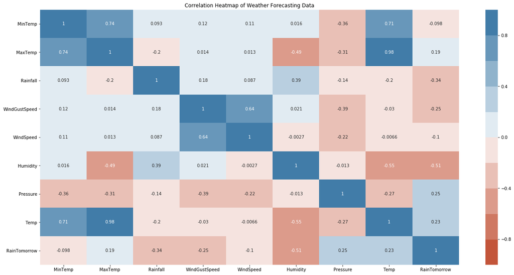

```python
plt.figure(figsize=(22,11))
plt.title('Correlation Heatmap of Weather Forecasting Data')
sb.heatmap(data.corr(), annot=True, vmin=-1, vmax=1, cmap=sb.diverging_palette(20, 240,n=10))
plt.show()
```

*From the correlation matrix, We see that Pressure has the highest positive correlation with Rain Tomorrow followed by Temp, whereas Humidity has a strong negative correlation followed by Rainfall and WindGustSpeed.*

*These variables strongly affect the target variable compared to remaining variables.*

## SECTION 2 : MODELLING

### Decision Tree Classification

*A Decision Tree is a simple representation for classifying problems. It is a Supervised Machine Learning where the data is continuously split according to a certain parameter.*

**Declaring feature and Target Variables**

```python
X = data.drop(['RainTomorrow'],axis=1)
y = data['RainTomorrow']
```

**One-Hot Encoding Categorical variables**

```python
X = pd.get_dummies(X,columns=['Location','WindGustDir','WindDir','RainToday'],drop_first=True)
```

**Splitting data into train and test set**

```python
X_train,X_test,y_train,y_test=train_test_split(X,y,test_size=0.3,random_state=0)
```

**Running a base Decision Tree Classifier model on train set**

```python
clf=DecisionTreeClassifier().fit(X_train,y_train)
```

**Making prediction on test set**

```python
y_pred=clf.predict(X_test)
```

**Confusion Matrix plot and Metrics**

*Evaluating the model by plotting a confusion matrix and checking metrics like accuracy, recall, precision, f1 score*

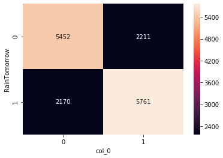

```python
sb.heatmap(pd.crosstab(y_test,y_pred),annot=True,fmt='d')
plt.show()
```

```python
print('Accuracy score is {0:.2f} %'.format(accuracy_score(y_test,y_pred)*100))
print('Recall Score is {0:.2f} %'.format(recall_score(y_test,y_pred)*100))
print('Precision Score is {0:.2f} %'.format(precision_score(y_test,y_pred)*100))
print('F1 score is {0:.2f} %'.format(f1_score(y_test,y_pred)*100))
```

```
Accuracy score is 71.91 %
Recall Score is 72.64 %
Precision Score is 72.27 %
F1 score is 72.45 %
```

**Plotting tree of base model**

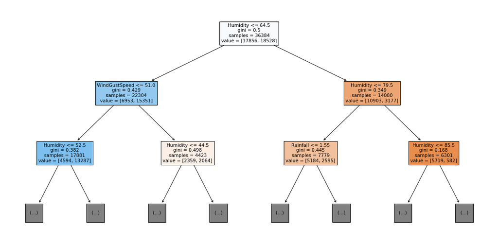

```python
plt.figure(figsize=(20,10))
plot_tree(clf,max_depth=2,filled=True,feature_names=X.columns)
plt.show()
```

**Classification report**

```python
print(classification_report(y_pred,y_test))
```

```
              precision    recall  f1-score   support

           0       0.71      0.72      0.71      7622
           1       0.73      0.72      0.72      7972

    accuracy                           0.72     15594
   macro avg       0.72      0.72      0.72     15594
weighted avg       0.72      0.72      0.72     15594
```

**Hyperparameter tuning for Decision Tree Classification**

*Performing GridSearch with all combinations of different values of minsplit, maxdepth and min_samples_leaf, max_leaf_nodes.*

```python
param_grid = {'criterion': ['gini', 'entropy'],
              'min_samples_split': [2, 10, 20],
              'max_depth': [5, 10, 20],
              'min_samples_leaf': [1, 5,10],
              'max_leaf_nodes': [2, 5, 10, 20]}
grid = GridSearchCV(clf, param_grid, cv=6, scoring='accuracy')
grid.fit(X_train, y_train)
```

```
GridSearchCV(cv=6, error_score=nan,
             estimator=DecisionTreeClassifier(ccp_alpha=0.0, class_weight=None,
                                              criterion='gini', max_depth=None,
                                              max_features=None,
                                              max_leaf_nodes=None,
                                              min_impurity_decrease=0.0,
                                              min_impurity_split=None,
                                              min_samples_leaf=1,
                                              min_samples_split=2,
                                              min_weight_fraction_leaf=0.0,
                                              presort='deprecated',
                                              random_state=None,
                                              splitter='best'),
             iid='deprecated', n_jobs=None,
             param_grid={'criterion': ['gini', 'entropy'],
                         'max_depth': [5, 10, 20],
                         'max_leaf_nodes': [2, 5, 10, 20],
                         'min_samples_leaf': [1, 5, 10],
                         'min_samples_split': [2, 10, 20]},
             pre_dispatch='2*n_jobs', refit=True, return_train_score=False,
             scoring='accuracy', verbose=0)
```

**Best parameters after running GridSearch and best score**

```python
print('best score is {:.2f}\n'.format(grid.best_score_*100))
grid.best_params_
```

```
best score is 75.58
```

```
{'criterion': 'gini',
 'max_depth': 5,
 'max_leaf_nodes': 20,
 'min_samples_leaf': 1,
 'min_samples_split': 2}
```

**Running Decision Tree using best parameters**

```python
dtree=DecisionTreeClassifier(criterion= 'gini',max_depth= 5,max_leaf_nodes= 20,min_samples_leaf= 1,min_samples_split= 2)

dtree=dtree.fit(X_train,y_train)
y_pred=dtree.predict(X_test)
```

**Confusion matrix and metrics of best model**

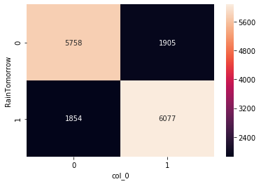

```python
sb.heatmap(pd.crosstab(y_test,y_pred),annot=True,fmt='d')
plt.show()
```

```python
print('Accuracy score is {0:.2f} %'.format(accuracy_score(y_test,y_pred)*100))
print('Recall Score is {0:.2f} %'.format(recall_score(y_test,y_pred)*100))
print('Precision Score is {0:.2f} %'.format(precision_score(y_test,y_pred)*100))
print('F1 score is {0:.2f} %'.format(f1_score(y_test,y_pred)*100))
```

```
Accuracy score is 75.89 %
Recall Score is 76.62 %
Precision Score is 76.13 %
F1 score is 76.38 %
```

**Classiffication Report of best model**

```python
print(classification_report(y_pred,y_test))
```

```
              precision    recall  f1-score   support

           0       0.75      0.76      0.75      7612
           1       0.77      0.76      0.76      7982

    accuracy                           0.76     15594
   macro avg       0.76      0.76      0.76     15594
weighted avg       0.76      0.76      0.76     15594
```

*The metrics of the Decision Tree Classifier, obtained by using the parameters from the GridSearch, are slightly improved compared to the base model.*

**Plotting tree of best model**

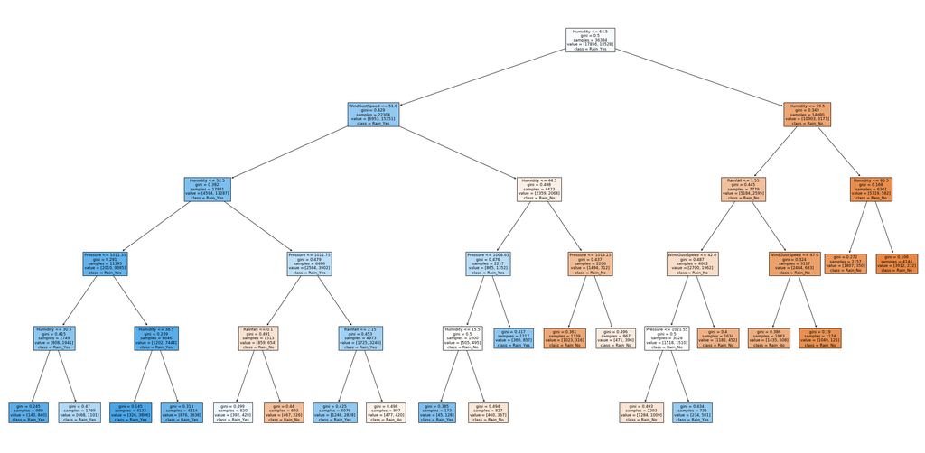

```python
plt.figure(figsize=(40,20))
plot_tree(dtree,filled=True,feature_names=X.columns,class_names=['Rain_No','Rain_Yes'])
plt.show()
```